# Gene Activity in Immune Cells for Detecting Adult-onset Still’s Disease

Registration number: 2021ICT36

# 1. Data

```r
cran_pkgs <- c("tidyverse", "pheatmap", "caret", "e1071", "ggrepel", "BiocManager")
bioc_pkgs <- c("GEOquery", "limma", "clusterProfiler", "org.Hs.eg.db", "enrichplot")

for (p in cran_pkgs) if (!requireNamespace(p, quietly = TRUE)) install.packages(p)
if (!requireNamespace("BiocManager", quietly = TRUE)) install.packages("BiocManager")
for (p in bioc_pkgs) if (!requireNamespace(p, quietly = TRUE)) {
  BiocManager::install(p, ask = FALSE, update = FALSE)
}

suppressPackageStartupMessages({
  library(tidyverse)
  library(GEOquery)
  library(limma)
  library(clusterProfiler)
  library(org.Hs.eg.db)
  library(enrichplot)
  library(pheatmap)
  library(caret)
  library(e1071)
  library(ggrepel)
})

set.seed(2026)
```

## 1.1 Source

The dataset is **GSE113645** taken from the NCBI Gene Expression Omnibus (GEO). It contains monocyte gene expression from patients with active AOSD, patients with inactive AOSD, and healthy controls. The study measured these profiles to investigate the role of PLAC8 in AOSD.

The series matrix file is read from `data/` at the repo root, and the parsed object is cached as an `.rds` file so later knits are fast.

```r
gse_id      <- "GSE113645"
data_dir    <- file.path(root, "data")
dir.create(data_dir, showWarnings = FALSE)
cache_file  <- file.path(data_dir, paste0(gse_id, ".rds"))
matrix_file <- file.path(data_dir, paste0(gse_id, "_series_matrix.txt.gz"))

# Show where R is looking, so a misplaced file is easy to spot
cat("Working directory:", normalizePath(getwd()), "\n")
```

```
## Working directory: C:\Users\kosal\Documents\Projects\AOSD_PROJECT\code
```

```r
# Search for a manually downloaded series matrix
find_local_matrix <- function() {
  search_dirs <- unique(c(data_dir, ".", path.expand("~/Downloads")))
  hits <- unlist(lapply(search_dirs, function(d) {
    if (!dir.exists(d)) return(NULL)
    list.files(d, pattern = paste0(gse_id, ".*series_matrix"),
               ignore.case = TRUE, full.names = TRUE)
  }))
  unique(hits)
}

if (file.exists(cache_file)) {
  gse_list <- readRDS(cache_file)
} else {
  if (!file.exists(matrix_file)) {
    hits <- find_local_matrix()
    if (length(hits) == 0) {
      stop("Series matrix file not found. R expected it at: ",
           normalizePath(matrix_file, mustWork = FALSE),
           "\nPlace GSE113645_series_matrix.txt.gz in the data/ folder ",
           "at the repository root, then knit again.", call. = FALSE)
    }
    cat("Found:", hits[1], "\nCopying it to:", matrix_file, "\n")
    file.copy(hits[1], matrix_file, overwrite = TRUE)
  }

  # Confirm the file is a GEO series matrix, not an HTML error page
  first_line <- readLines(gzfile(matrix_file), n = 1, warn = FALSE)
  if (!grepl("^!Series", first_line[1])) {
    stop("This file does not look like a GEO series matrix. First line: ",
         first_line[1], call. = FALSE)
  }

  gse_list <- getGEO(filename = matrix_file, GSEMatrix = TRUE)

  # A local file returns a single ExpressionSet, so wrap it in a list
  if (!is.list(gse_list)) gse_list <- list(gse_list)
  saveRDS(gse_list, cache_file)
}

# Keep the platform with the most samples if the series has more than one
eset <- gse_list[[which.max(sapply(gse_list, ncol))]]
cat("Platform:", annotation(eset), "| Probes:", nrow(eset), "| Samples:", ncol(eset), "\n")
```

```
## Platform: GPL570 | Probes: 54675 | Samples: 9
```

## 1.2 Variables and sample groups

```r
pheno     <- pData(eset)
char_cols <- grep("characteristics", colnames(pheno), value = TRUE)

for (cc in char_cols) {
  cat("\n", cc, "\n")
  print(table(pheno[[cc]], useNA = "ifany"))
}
```

```
##
##  characteristics_ch1
##
##   disease state: active ASD      disease state: healthy
##                           3                           3
## disease state: inactive ASD
##                           3
##
##  characteristics_ch1.1
##
## tissue: blood
##             9
##
##  characteristics_ch1.2
##
## cell type: CD14+ monocytes
##                          9
##
##  characteristics_ch1.3
##
## gender: Female   gender: Male
##              6              3
##
##  characteristics_ch1.4
##
## age: 42 years old age: 43 years old age: 45 years old age: 48 years old
##                 2                 2                 1                 1
## age: 60 years old age: 61 years old
##                 1                 2
```

```r
group_col <- char_cols[1]
group_raw <- pheno[[group_col]]

# Inactive is checked before Active because "inactive" contains the word "active"
group <- case_when(
  grepl("healthy|control|normal", group_raw, ignore.case = TRUE) ~ "Healthy",
  grepl("inactive", group_raw, ignore.case = TRUE)              ~ "Inactive",
  grepl("active", group_raw, ignore.case = TRUE)                ~ "Active",
  TRUE ~ NA_character_
)

if (anyNA(group)) {
  stop("Unmapped labels: ", paste(unique(group_raw[is.na(group)]), collapse = "; "))
}

group <- factor(group, levels = c("Healthy", "Inactive", "Active"))
table(group)
```

```
## group
##  Healthy Inactive   Active
##        3        3        3
```

# 2. Data cleaning and preprocessing

```r
expr <- exprs(eset)
cat("Missing values:", sum(is.na(expr)), "\n")
```

```
## Missing values: 0
```

```r
cat("Value range:", round(range(expr, na.rm = TRUE), 2), "\n")
```

```
## Value range: 5.02 14.03
```

```r
# Log2-transform if values are still on the raw intensity scale
if (max(expr, na.rm = TRUE) > 100) expr <- log2(expr + 1)

# Remove probes with missing values
expr <- expr[complete.cases(expr), ]
cat("Probes after removing missing values:", nrow(expr), "\n")
```

```
## Probes after removing missing values: 54675
```

## 2.1 Mapping probes to genes

Microarrays measure probes, and several probes can target the same gene. Probes are mapped to gene symbols, and when a gene has more than one probe, the probe with the highest mean expression is kept.

```r
fd       <- fData(eset)
sym_col  <- grep("symbol", colnames(fd), ignore.case = TRUE, value = TRUE)[1]
if (is.na(sym_col)) stop("No gene symbol column found; annotate probes with the platform file.")
cat("Using annotation column:", sym_col, "\n")
```

```
## Using annotation column: Gene Symbol
```

```r
ann <- tibble(
  probe  = rownames(expr),
  symbol = sub(" ///.*", "", fd[rownames(expr), sym_col])
) %>%
  filter(!is.na(symbol), symbol != "")

ann$mean_expr <- rowMeans(expr[ann$probe, ])

collapsed <- ann %>%
  group_by(symbol) %>%
  slice_max(mean_expr, n = 1, with_ties = FALSE) %>%
  ungroup()

expr_gene <- expr[collapsed$probe, ]
rownames(expr_gene) <- collapsed$symbol
cat("Probes:", nrow(expr), "-> unique genes:", nrow(expr_gene), "\n")
```

```
## Probes: 54675 -> unique genes: 22880
```

## 2.2 Filtering low-expression genes

Genes in the lowest quartile of mean expression are mostly noise and inflate the multiple-testing burden, so they are removed.

```r
gene_means <- rowMeans(expr_gene)
expr_gene  <- expr_gene[gene_means > quantile(gene_means, 0.25), ]
cat("Genes retained:", nrow(expr_gene), "\n")
```

```
## Genes retained: 17138
```

```r
sample_info <- tibble(sample = colnames(expr_gene), group = group)
```

# 3. Exploratory data analysis

## 3.1 Distribution of expression per sample

Comparable distributions across samples indicate that technical normalisation worked. Large shifts would suggest batch effects.

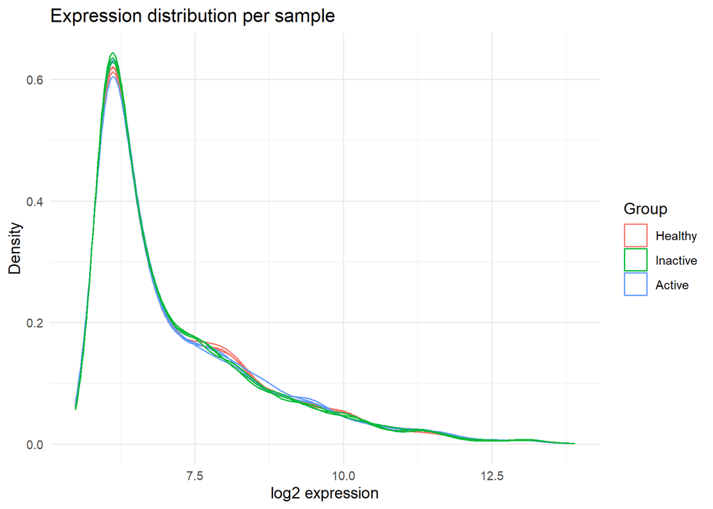

```r
set.seed(1)
idx <- sample(nrow(expr_gene), min(3000, nrow(expr_gene)))

p_density <- as_tibble(expr_gene[idx, ], rownames = "gene") %>%
  pivot_longer(-gene, names_to = "sample", values_to = "expression") %>%
  left_join(sample_info, by = "sample") %>%
  ggplot(aes(expression, colour = group, group = sample)) +
  geom_density(alpha = 0.4) +
  labs(title = "Expression distribution per sample",
       x = "log2 expression", y = "Density", colour = "Group") +
  theme_minimal()

save_fig(p_density, "01_expression_density")
```

## 3.2 Principal component analysis

PCA shows whether the largest sources of variation follow disease group. If they do not, technical factors may dominate.

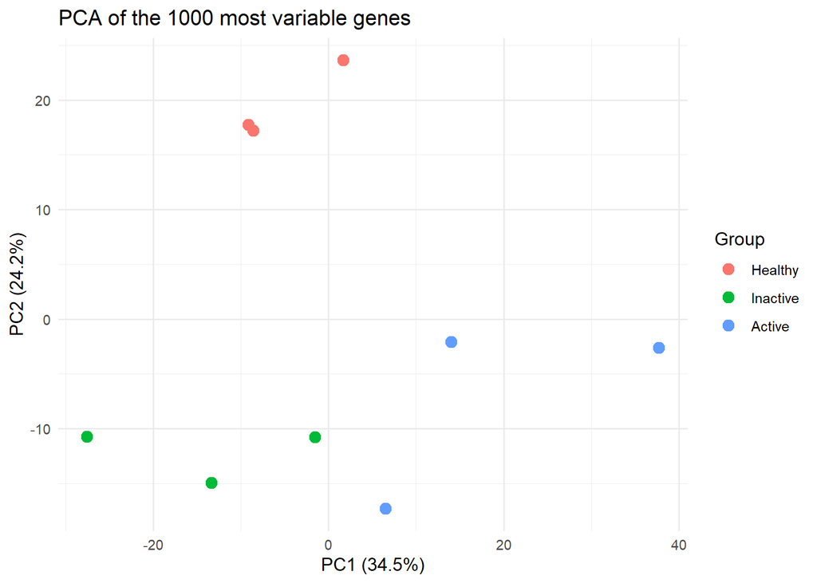

```r
gene_var  <- apply(expr_gene, 1, var)
top_genes <- names(sort(gene_var, decreasing = TRUE))[1:1000]

pca     <- prcomp(t(expr_gene[top_genes, ]), scale. = TRUE)
var_pct <- round(100 * summary(pca)$importance[2, 1:2], 1)

p_pca <- as_tibble(pca$x[, 1:2], rownames = "sample") %>%
  left_join(sample_info, by = "sample") %>%
  ggplot(aes(PC1, PC2, colour = group)) +
  geom_point(size = 3) +
  stat_ellipse(linetype = "dashed", show.legend = FALSE) +
  labs(title = "PCA of the 1000 most variable genes",
       x = paste0("PC1 (", var_pct[1], "%)"),
       y = paste0("PC2 (", var_pct[2], "%)"),
       colour = "Group") +
  theme_minimal()

save_fig(p_pca, "02_pca_top1000_genes")
```

## 3.3 Sample correlation

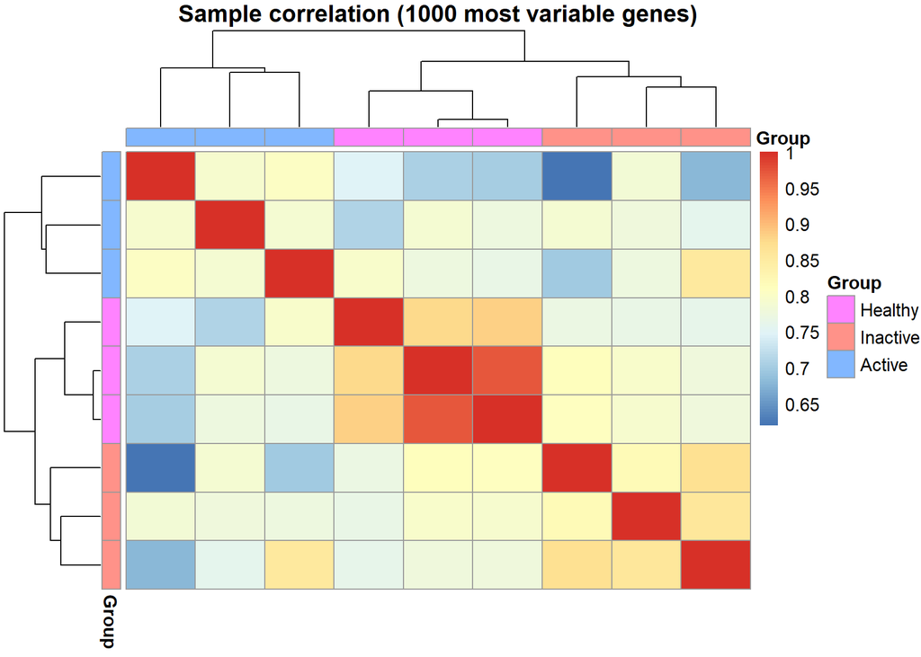

```r
annot_col <- data.frame(Group = group, row.names = colnames(expr_gene))

ph_cor <- pheatmap(cor(expr_gene[top_genes, ]),
                   annotation_col = annot_col,
                   annotation_row = annot_col,
                   show_rownames  = FALSE,
                   show_colnames  = FALSE,
                   main = "Sample correlation (1000 most variable genes)")
```

```r
save_pheat(ph_cor, "03_sample_correlation")
```

# 4. Main analysis

## 4.1 Differential expression with limma

`limma` fits a linear model to each gene and uses empirical Bayes moderation of the variance, which is well suited to small sample sizes. Results are corrected for multiple testing with the Benjamini–Hochberg method.

```r
design <- model.matrix(~ 0 + group)
colnames(design) <- levels(group)

fit <- lmFit(expr_gene, design)

contr <- makeContrasts(
  Active_vs_Healthy   = Active - Healthy,
  Inactive_vs_Healthy = Inactive - Healthy,
  Active_vs_Inactive  = Active - Inactive,
  levels = design
)

fit2 <- eBayes(contrasts.fit(fit, contr))
```

```r
get_de <- function(coef) {
  topTable(fit2, coef = coef, number = Inf) %>% rownames_to_column("gene")
}

res_ah <- get_de("Active_vs_Healthy")
res_ih <- get_de("Inactive_vs_Healthy")
res_ai <- get_de("Active_vs_Inactive")

n_sig <- function(r) sum(r$adj.P.Val < 0.05 & abs(r$logFC) > 1)

tibble(
  comparison  = c("Active vs Healthy", "Inactive vs Healthy", "Active vs Inactive"),
  significant = c(n_sig(res_ah), n_sig(res_ih), n_sig(res_ai))
)
```

| comparison | significant |
| --- | --- |
| Active vs Healthy | 12 |
| Inactive vs Healthy | 0 |
| Active vs Inactive | 6 |

The criteria for a significant gene are an adjusted p-value below 0.05 and an absolute log2 fold change above 1.

## 4.2 Volcano plot

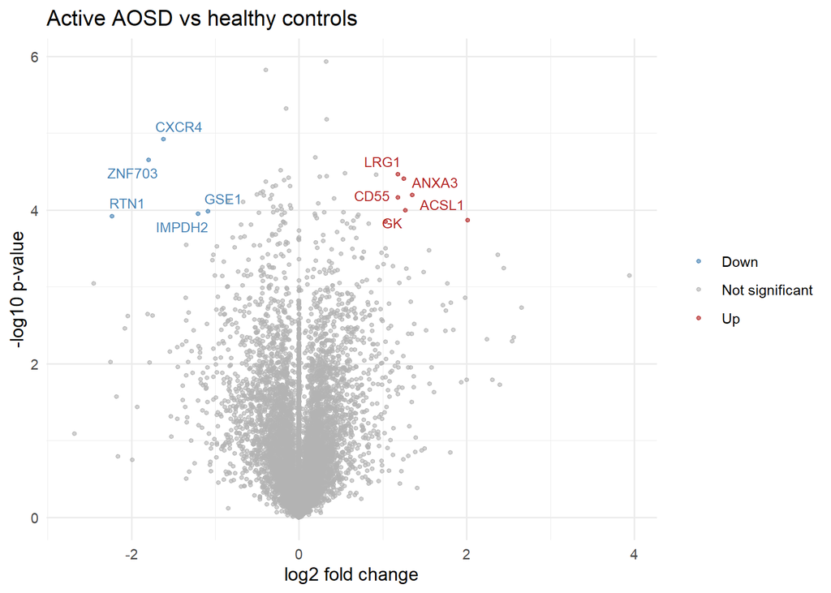

```r
volcano_plot <- function(res, title) {
  df <- res %>%
    mutate(status = case_when(
      adj.P.Val < 0.05 & logFC > 1  ~ "Up",
      adj.P.Val < 0.05 & logFC < -1 ~ "Down",
      TRUE ~ "Not significant"
    ))

  labels_df <- df %>%
    filter(status != "Not significant") %>%
    slice_min(adj.P.Val, n = 10)

  ggplot(df, aes(logFC, -log10(P.Value), colour = status)) +
    geom_point(alpha = 0.6, size = 1) +
    geom_text_repel(data = labels_df, aes(label = gene),
                    size = 3, show.legend = FALSE) +
    scale_colour_manual(values = c(Up = "firebrick", Down = "steelblue",
                                   "Not significant" = "grey70")) +
    labs(title = title, x = "log2 fold change",
         y = "-log10 p-value", colour = NULL) +
    theme_minimal()
}

p_volcano <- volcano_plot(res_ah, "Active AOSD vs healthy controls")
save_fig(p_volcano, "04_volcano_active_vs_healthy")
```

## 4.3 Heatmap of the top differentially expressed genes

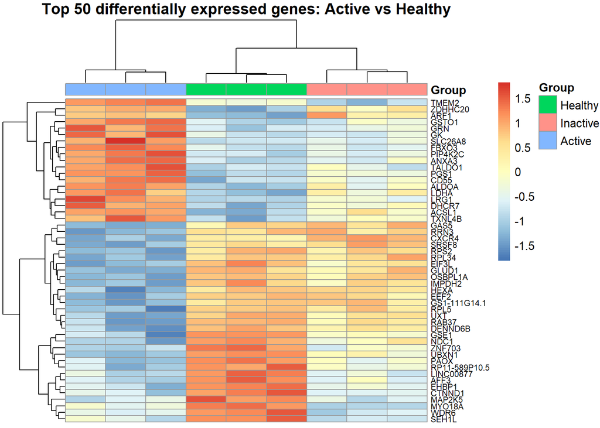

```r
top50 <- res_ah %>% arrange(adj.P.Val) %>% slice_head(n = 50) %>% pull(gene)

ph_top50 <- pheatmap(expr_gene[top50, ],
                     annotation_col = annot_col,
                     scale = "row",
                     show_colnames = FALSE,
                     fontsize_row = 7,
                     main = "Top 50 differentially expressed genes: Active vs Healthy")
```

```r
save_pheat(ph_top50, "05_top50_de_heatmap", h = 7)
```

# 5. Interpretation of gene sets: GO enrichment

```r
sig_up   <- res_ah %>% filter(adj.P.Val < 0.05, logFC >  1) %>% pull(gene)
sig_down <- res_ah %>% filter(adj.P.Val < 0.05, logFC < -1) %>% pull(gene)
cat("Up in active AOSD:", length(sig_up), "| Down in active AOSD:", length(sig_down), "\n")
```

```
## Up in active AOSD: 7 | Down in active AOSD: 5
```

```r
run_go <- function(genes) {
  if (length(genes) < 10) return(NULL)
  enrichGO(gene          = genes,
           universe      = rownames(expr_gene),
           OrgDb         = org.Hs.eg.db,
           keyType       = "SYMBOL",
           ont           = "BP",
           pvalueCutoff  = 0.05,
           pAdjustMethod = "BH")
}

go_up   <- run_go(sig_up)
go_down <- run_go(sig_down)
```

```r
if (!is.null(go_up) && nrow(as.data.frame(go_up)) > 0) {
  p_go_up <- dotplot(go_up, showCategory = 15) +
    ggtitle("GO biological processes: higher in active AOSD")
  save_fig(p_go_up, "06_go_up_active", w = 8, h = 6)
} else {
  cat("No significant GO terms for the up-regulated genes.")
}
```

```
## No significant GO terms for the up-regulated genes.
```

```r
if (!is.null(go_down) && nrow(as.data.frame(go_down)) > 0) {
  p_go_down <- dotplot(go_down, showCategory = 15) +
    ggtitle("GO biological processes: lower in active AOSD")
  save_fig(p_go_down, "07_go_down_active", w = 8, h = 6)
} else {
  cat("No significant GO terms for the down-regulated genes.")
}
```

```
## No significant GO terms for the down-regulated genes.
```